# Albemarle County Child Welfare Study

Foster Care Addendum

Michele Claibourn

5/27/2022

The initial analysis of the 2021 Albemarle County Child Welfare Study, conducted on behalf of the Albemarle County Department of Social Services (DSS), focused on initial decision points in the child welfare case flow, including the characteristics of referrals to Child Protective Services, the post-referral outcomes, and repeat referrals. This follow up report supplements that work by examining a different set of outcomes – those for children in foster care.

When DSS determines that in-home family preservation services are not sufficient to keep a child safe, a child may be temporarily removed from their home and placed in foster care. Here we analyze the nature of foster care placements, the number of placement transitions a child experiences and the amount of time children spend in foster care, and the paty by which children exit foster care. As in the initial report, we ask whether there is evidence of racial or other disparities, whether one group of children is more likely to experience a particular outcome than another.

As in the original study, we rely on administrative data provided by the Virginia Department of Social Services (VDSS) in collaboration with the Albemarle County Department of Social Services. All data were initially extracted and de-identified by the Office of Research and Planning at VDSS.

Key Data Sources include:

- Foster care data: Children in foster care anytime between between January 1, 2017 to December 31, 2019. Includes race and gender of the child; age of child upon entering custody, date child entered custody, child’s current placement type, date child exited custody, and reason for exit.
- Foster care placement history data: Placement history of foster care clients in care between January 1, 2017 to December 31, 2019. Includes date of entry for each new placement, type of placement, date of exist for each placement, and reason for exit from placement.

In the three year period from January 2017 through December 2019, 219 children were in foster care for some interval. This does not mean that more than 200 children were in foster care at any single time.

# Racial Disproportionality

We start by looking at who is in foster care within the county relative to the population of children who reside in the county. In particular, we examine whether some populations of children are over-represented in the county’s foster care system.

For referrals to Child Protective Services, we saw that Black and Multiracial children were disproportionately represented relative to the population of children they compose. In both cases, they made up twice the proportion of referred children (at 22.5% and 6.6%) than of the children in the county (at 11.3% and 3.4%). Figure 1 below shows the equivalent comparisons for children in foster care.

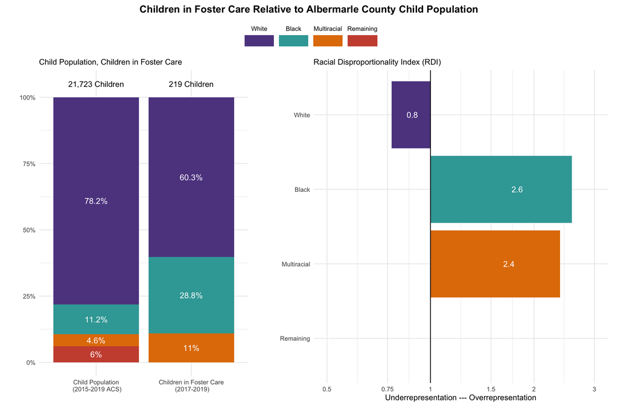

The removal of a child from the home is one of the most challenging outcomes in the child welfare system decision flow, pursued only with court commitment or parental agreement. According to the Joint Legislative Audit and Review Commission’s report, Virginia, overall, has the lowest rate of removing children from their homes, with 2.6 children per 1,000 in foster care (JLARC 2018).

The JLARC study does not differentiate by race, but the Albemarle County records suggest that not all children are equally likely to be removed from the home. The racial disproportionality mirrors that found in Charlottesville city as well (Claibourn, McClintock et al 2018).

# Type of Placement

When children enter foster care, there are multiple out-of-home environments in which they could be placed. The majority of placement settings during this period – 73% – were in a foster family.

One-third of placements were with a relative foster family or kin placement. Kinship placements tend to be more stable than non-kinship placements and have been found in some research to improve the likelihood of legal permanence (Koh 2010); when possible, social services seeks to place children in kinship foster care. Forty percent of placements were with non-relative foster families. This compares favorably with the JLARC’s report noting that in 2016, only six percent of Virginia children in foster care were in relative care, well below the national average of 32%. The remaining children are some form of congregate care, a group home or institution (6%) or in a supervised independent living setting (20%).

The biggest differences is among multiracial children who are the most likely to be in a relative foster family. Indeed, they are twice as likely as white children to be in such a placement (though multiracial children make up the smallest group). While one-third of Black and multiracial children were in non-relative foster families, this was the most common placement for White children, with 43% of white children in these environments.

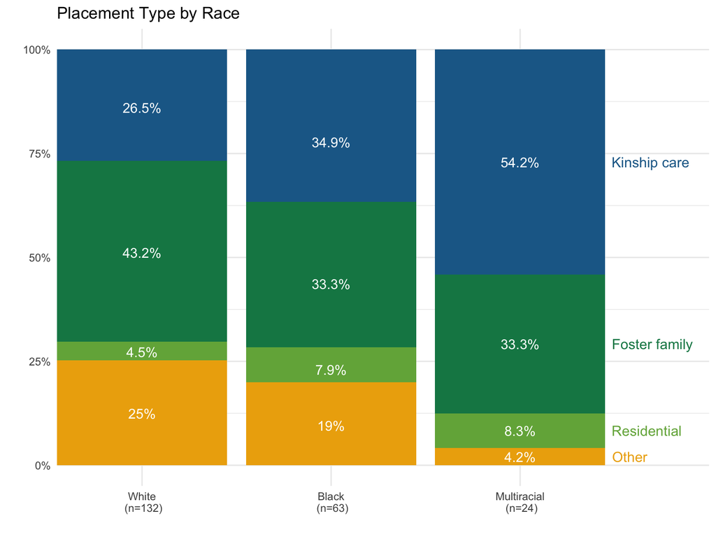

The differences in placements are shaped by a variety of constraints – the presence of extended family, the resources within a family’s network, the needs of a child – and not a direct result of race. These constraints, though, may themselves vary by race.

Additional modeling of the likelihood of a kinship placement indicates no differences by a child’s gender. Age, though, does matter: the older a child is at the time of removal, the less likely they are to be in a kinship setting.

# Placement Stability

Children in foster care often experience multiple transitions between out-of-home placements. Placement instability – more placement transitions, shorter stays in a placement – can be traumatic for children and child care professionals work to minimize the number of foster care placements as well as the overall time spent in foster care.

The placement history for children in foster care during this period indicates that the number of unique placements experienced by a child ranges from one to more than 30. The median number of placements is two, half of the children experience only one or two different out-of-home environments and half of the children experience more. The average number of distinct placements among the children in this study is three.

To assess these outcomes by race, we examine the distribution of number of placements experienced by children in foster care during this three-year period in Figure 3.

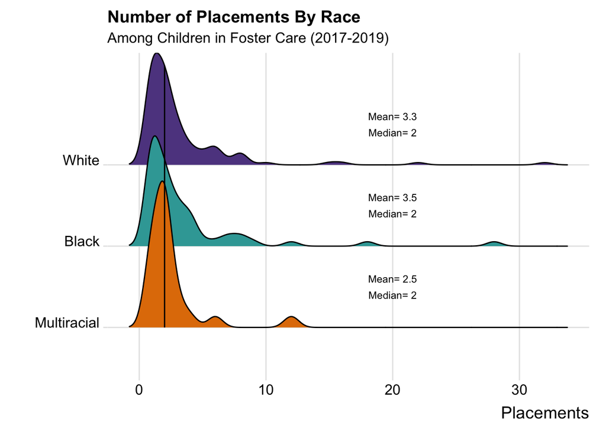

Importantly, the distributions are very similar across racial identification. The median number of placements for multiracial, Black, and white children is two. While the average number of placement transitions is slightly higher for Black children in foster care, the differences are neither large nor statistically discernibly different from zero. The stability of children in foster care does not vary by race.

Additional modeling of the number of placements again indicates no notable differences by a child’s gender. A child’s age upon entering foster care, though, is associated with the number of transitions, with older children experiencing a higher number of unique out-of-home placements.

Another indicator of placement stability is the time children spend in each foster care setting. Figure 4 compares the distribution of the number of weeks a child spends in each placement by race. Here, again, the patterns are very similar across racial categories, with the average length of a placement hovering around a year for all children.

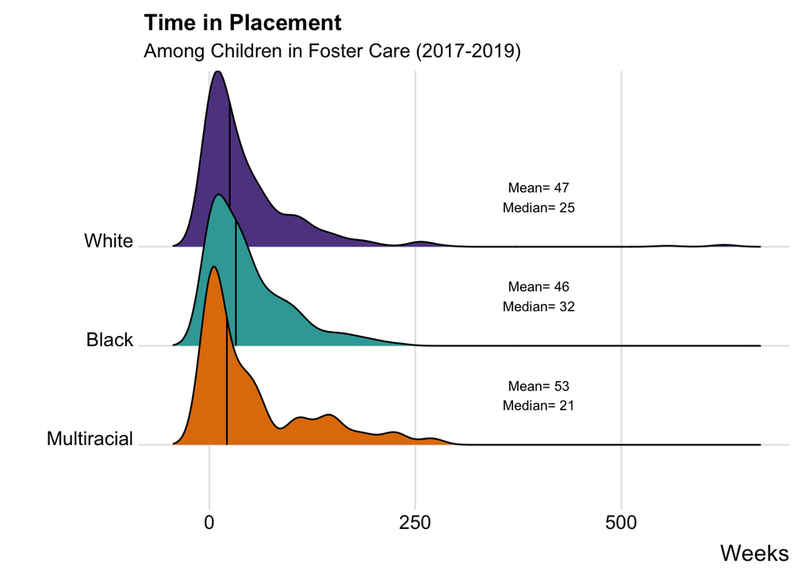

While no differences are apparent by race, additional modeling of the length of time in a placement suggests, again, that age affects stability, with older children experiencing short stays for a placement, on average.

# Time in Foster Care

In Albemarle County, the median time in foster care during the study period was 78 weeks, or about 18 months. This is nearly identical to the median length of time in foster care within the state overall, 19 months (JLARC 2018). Figure 5 shows the distribution of time in foster care by the racial identification of children in care.

While white children experience slightly shorter durations in foster care relative to Black and multiracial children, the differences are not large enough to be statistically discernibly different at conventional levels. But here is the first case where the shape of the distributions begin to diverge, with multiracial children evidencing a larger proportion facing especially long durations of care (note the long and heavy area to the right of the median).

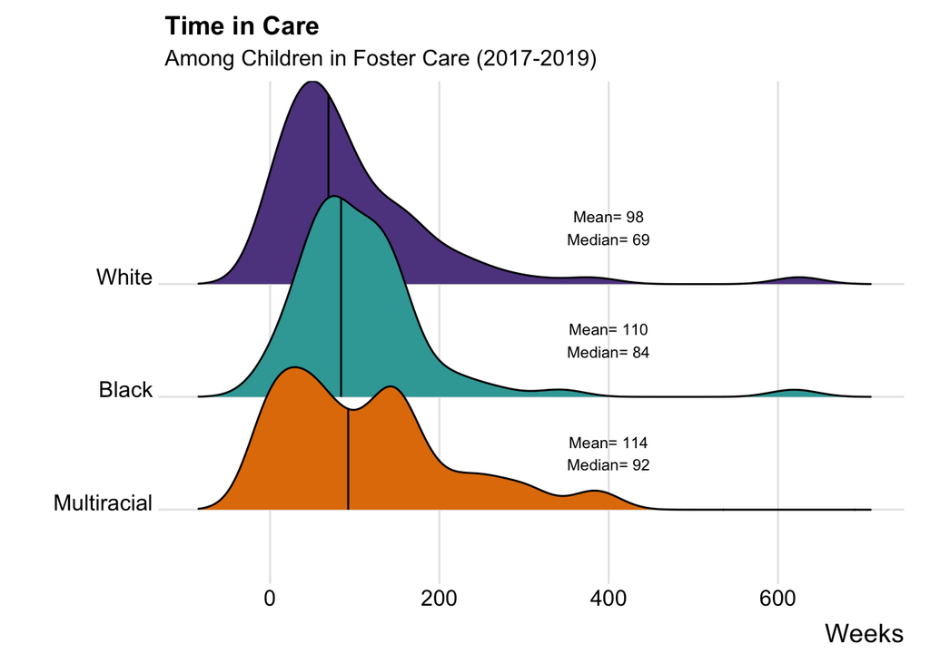

# Exit from Care

While in foster care, child welfare professionals work with children and their families to develop a permanency plan. Family reunification is the expected permanency plan for most children, though this is not viable in all circumstances.

Among the children who were in foster care during the 2017-2019 time period, 130 had been discharged and 89 remained in care at the end of 2019. The reasons provided for exit from foster care included: reunification (42%), custody transfer to another relative (10%), adoption (22%), emancipation (22%), custody transfer to another agency (2%), and child is a runaway (2%). Because so few children are categorized as being transferred to another agecy or running away, these categories are combined in the subsequent analysis.

These outcomes are somewhat better than the overall state outcomes. The JLARC report indicates that 54% of foster care children in Virginia who were 12 or over when entering foster care age out of the foster care system. Another 26% are reunified with their families. Restricting the records to children who entered foster care at age 12 or over, 51% of those exiting the foster care system in this period were emancipated and 31% were reunified with their families.

Figure 6 presents these exit outcomes by the race of the child.

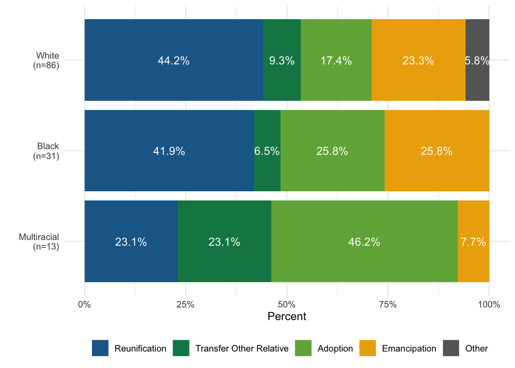

Black and white children have very similar patterns of leaving foster care, with the plurality reunified with birth parents, and about a quarter aging out. Because multiracial children made up a smaller set of children in foster care during the study period, they comprise an especially small set of children leaving foster care. Consequently, these numbers should be interpreted with some caution, since a change in a few outcomes could look like a big difference in the reported percents. Nevertheless, this group of children experienced the lowest rate of family reunification and a comparably higher rate of adoption.

Additional modeling of the likelihood of exiting to family reunification showed no differences by a child’s gender. As children enter foster care at an older age, however, they are less likely to leave foster care by family reunification.

The presence of children in foster care within Albemarle County evidences a similar racial disproportionality as initial referrals to Child Protective Services. The overrepresentation of Black and multiracial children, relative to their numbers in the county’s child population, reflects a troubling consistency across the continuum of child welfare services.

There are not, however, consistent patterns of differential experiences by race within foster care.

While the analysis presented has focused on racial differences, additional modeling of these outcomes generally revealed stronger effects for the age of a child upon entering care. Older children were less likely to be in kinship care, likely to experience more placement transitions and spend less time in a placement, and were less likely to exit foster care for family reunification.

# References

- Joint Legislative Audit and Review Commission (JLARC). 2018. “Improving Virginia’s Foster Care System.” Report to the Governor and the General Assembly of Virginia, Richmond, VA. http://jlarc.virginia.gov/pdfs/reports/Rpt513-2.pdf
- Claibourn, Michele, Charlotte McClintock, et al. 2018. “Charlottesville Child Welfare Study.” Prepared by the UVA Public Interest Data Lab for the Charlottesville Department of Social Services. Charlottesville, VA. https://doi.org/10.18130/v3-1j50-3z57
[^1]: In the child referral data, Hispanic ethnicity of children was captured in addition to racial identity. In the foster care data, we have access only to the racial identity of children. Consequently, the comparative population data only accounts for race, making the number and proportion of racial categories somewhat higher than in the earlier analysis which grouped Hispanic children separately.
[^2]: Among the foster care data, only a small number of children were identified with a racial category other than Black or white and several of these were also multiracial. Thus, the foster care analysis uses only these three groups – white, Black, and multiracial.